# Explaining Black-Box Models through Counterfactuals

JuliaCon 2022

Patrick Altmeyer

## Overview

- The Problem with Black Boxes ⬛
  - What are black-box models? Why do we need explainability?
- Enter: Counterfactual Explanations 🔮
  - What are they? What are they not?
- Counterfactual Explanations in Julia (and beyond!) 📦
  - Introducing: [`CounterfactualExplanations.jl`](https://github.com/juliatrustworthyai/CounterfactualExplanations.jl)
  - Package architecture
  - Usage examples - what can it do?
- Goals and Ambitions 🎯
  - Future developments - where can it go?
  - Contributor’s guide

# The Problem with Black Boxes ⬛

## Short Lists, Pandas and Gibbons

> From **human** to **data-driven** decision-making …
- Black-box models like deep neural networks are being deployed virtually everywhere.
- Includes safety-critical and public domains: health care, autonomous driving, finance, …
- More likely than not that your loan or employment application is handled by an algorithm.

> … where black boxes are recipe for disaster.
- We have no idea what exactly we’re cooking up …
  - Have you received an automated rejection email? Why didn’t you “mEet tHe sHoRtLisTiNg cRiTeRia”? 🙃
- … but we do know that some of it is junk.

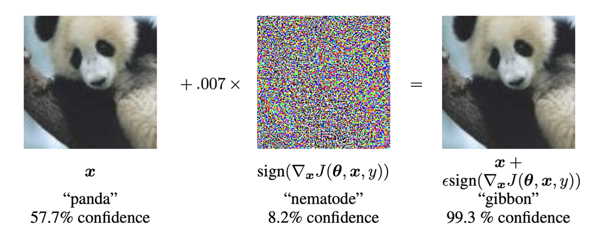

Figure 1: Adversarial attacks on deep neural networks. Source: Goodfellow et al. (2015)

## “Weapons of Math Destruction”

> “You cannot appeal to (algorithms). They do not listen. Nor do they bend.”

> — Cathy O’Neil in [*Weapons of Math Destruction*](https://en.wikipedia.org/wiki/Weapons_of_Math_Destruction), 2016

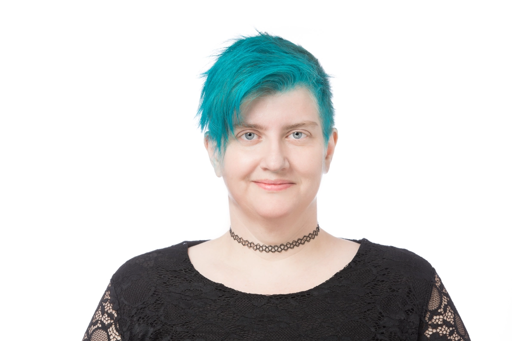

Figure 2: Cathy O’Neil. Source: Cathy O’Neil a.k.a. [mathbabe](https://mathbabe.org/contact/).

- If left unchallenged, these properties of black-box models can create undesirable dynamics in automated decision-making systems:
  - Human operators in charge of the system have to rely on it blindly.
  - Individuals subject to the decisions generally have no way to challenge their outcome.

## Towards Trustworthy AI

Ground Truthing

Probabilistic Models

Counterfactual Reasoning

## Towards Trustworthy AI

Ground Truthing

Probabilistic Models

Counterfactual Reasoning

#### Current Standard in ML

We typically want to maximize the likelihood of observing $\mathcal{D}_n$ under given parameters (Murphy 2022):

$$\theta^* = \arg \max_{\theta} p(\mathcal{D}_n|\theta)
\tag{1}$$

Compute an MLE (or MAP) point estimate $\hat\theta = \mathbb{E} \theta^*$ and use **plugin** approximation for prediction:

$$p(y|x,\mathcal{D}_n) \approx p(y|x,\hat\theta)
\tag{2}$$

- In an ideal world we can just use parsimonious and interpretable models like GLM (Rudin 2019), for which in many cases we can rely on asymptotic properties of $\theta$ to quantify uncertainty.
- In practice these models often have performance limitations.
- Black-box models like deep neural networks are popular, but they are also the very opposite of parsimonious.

#### Objective

## Towards Trustworthy AI

Ground Truthing

Probabilistic Models

Counterfactual Reasoning

#### Objective

> […] deep neural networks are typically very underspecified by the available data, and […] parameters [therefore] correspond to a diverse variety of compelling explanations for the data. (Wilson 2020)

In this setting it is often crucial to treat models probabilistically!

$$p(y|x,\mathcal{D}_n) = \int p(y|x,\theta)p(\theta|\mathcal{D}_n)d\theta
\tag{3}$$

> Probabilistic models covered briefly today. More in my other talk on Laplace Redux …

## Towards Trustworthy AI

Ground Truthing

Probabilistic Models

Counterfactual Reasoning

> We can now make predictions – great! But do we know how the predictions are actually being made?

#### Objective

With the model trained for its task, we are interested in understanding how its predictions change in response to input changes.

$$\nabla_x p(y|x,\mathcal{D}_n;\hat\theta)
\tag{4}$$

- Counterfactual reasoning (in this context) boils down to simple questions: what if $x$ (factual) $\Rightarrow$ $x\prime$ (counterfactual)?
- By strategically perturbing features and checking the model output, we can (begin to) understand how the model makes its decisions.
- Counterfactual Explanations always have full fidelity by construction (as opposed to surrogate explanations, for example).

> Important to realize that we are keeping $\hat\theta$ constant!

# Enter: Counterfactual Explanations 🔮

## A Framework for Counterfactual Explanations

> Even though […] interpretability is of great importance and should be pursued, explanations can, in principle, be offered without opening the “black box”. (Wachter et al. 2017)

#### Framework

Objective originally proposed by Wachter et al. (2017) is as follows

$$\min_{x\prime \in \mathcal{X}} h(x\prime) \ \ \ \mbox{s. t.} \ \ \ M(x\prime) = t
\tag{5}$$

where $h$ relates to the complexity of the counterfactual and $M$ denotes the classifier.

Typically this is approximated through regularization:

$$x\prime = \arg \min_{x\prime} \ell(M(x\prime),t) + \lambda h(x\prime)
\tag{6}$$

#### Intuition

[figure not shown]

Figure 3: A cat performing gradient descent in the feature space à la Wachter et al. (2017).

## Counterfactuals … as in Adversarial Examples?

> Yes and no!

While both are methodologically very similar, adversarial examples are meant to go undetected while CEs ought to be meaningful.

> Effective counterfactuals should meet certain criteria ✅
- **closeness**: the average distance between factual and counterfactual features should be small (Wachter et al. (2017))
- **actionability**: the proposed feature perturbation should actually be actionable (Ustun et al. (2019), Poyiadzi et al. (2020))
- **plausibility**: the counterfactual explanation should be plausible to a human (Joshi et al. (2019))
- **unambiguity**: a human should have no trouble assigning a label to the counterfactual (Schut et al. (2021))
- **sparsity**: the counterfactual explanation should involve as few individual feature changes as possible (Schut et al. (2021))
- **robustness**: the counterfactual explanation should be robust to domain and model shifts (Upadhyay et al. (2021))
- **diversity**: ideally multiple diverse counterfactual explanations should be provided (Mothilal et al. (2020))
- **causality**: counterfactual explanations reflect the structural causal model underlying the data generating process (Karimi et al. (2020), Karimi et al. (2021))

## Counterfactuals … as in Causal Inference?

> NO!

**Causal inference**: counterfactuals are thought of as unobserved states of the world that we would like to observe in order to establish causality.

- The only way to do this is by actually interfering with the state of the world: $p(y|do(x),\theta)$.
- In practice we can only move some individuals to the counterfactual state of the world and compare their outcomes to a control group.
- Provided we have controlled for confounders, properly randomized, … we can estimate an average treatment effect: $\hat\theta$.

**Counterfactual Explanations**: involves perturbing features **after** some model has been trained.

- We end up comparing **modeled outcomes** $p(y|x,\hat\phi)$ and $p(y|x\prime,\hat\phi)$ for individuals.
- We have **not** magically solved causality.

> The number of ostensibly pro data scientists confusing themselves into believing that "counterfactual explanations" capture real-world causality is just staggering🤦‍♀️. Where do we go from here? How can a community that doesn't even understand what's already known make advances?

> — Zachary Lipton (@zacharylipton) [June 20, 2022](https://twitter.com/zacharylipton/status/1538952312781168640?ref_src=twsrc%5Etfw)

## Probabilistic Methods for Counterfactual Explanations

When people say that counterfactuals should look **realistic** or **plausible**, they really mean that counterfactuals should be generated by the same Data Generating Process (DGP) as the factuals:

$$x\prime \sim p(x)$$

But how do we estimate $p(x)$? Two probabilistic approaches …

- APPROACH 1: use the model itself
- APPROACH 2: use some generative model

Schut et al. (2021) note that by maximizing predictive probabilities $\sigma(M(x\prime))$ for **probabilistic** models $M\in\mathcal{\widetilde{M}}$ one implicitly minimizes **epistemic** and **aleotoric** uncertainty.

$$x\prime = \arg \min_{x\prime} \ell(M(x\prime),t) \ \ \ , \ \ \ M\in\mathcal{\widetilde{M}}
\tag{7}$$

[figure not shown]

Figure 4: A cat performing gradient descent in the feature space à la Schut et al. (2021)

Instead of perturbing samples directly, some have proposed to instead traverse a lower-dimensional latent embedding learned through a generative model (Joshi et al. 2019).

$$z\prime = \arg \min_{z\prime} \ell(M(dec(z\prime)),t) + \lambda h(x\prime)
\tag{8}$$

and

$$x\prime = dec(z\prime)$$

where $dec(\cdot)$ is the decoder function.

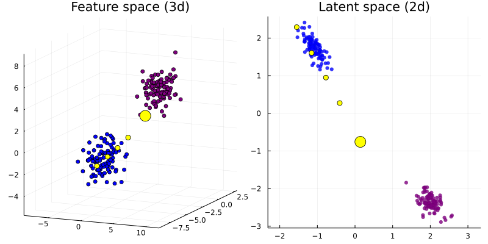

Figure 5: Counterfactual (yellow) generated through latent space search (right panel) following Joshi et al. (2019). The corresponding counterfactual path in the feature space is shown in the left panel.

# Counterfactual Explanations in Julia (and beyond!)

## Limited Software Availability

> Work currently scattered across different GitHub repositories …
- Only one unifying Python library: CARLA (Pawelczyk et al. 2021).
  - Comprehensive and (somewhat) extensible.
  - But not language-agnostic and some desirable functionality not supported.
  - Also not composable: each generator is treated as different class/entity.
- Both R and Julia lacking any kind of implementation.

[figure not shown]

Photo by [Volodymyr Hryshchenko](https://unsplash.com/@lunarts?utm_source=unsplash&utm_medium=referral&utm_content=creditCopyText) on [Unsplash](https://unsplash.com/s/photos/rubiks-cube?utm_source=unsplash&utm_medium=referral&utm_content=creditCopyText).

## Enter: `CounterfactualExplanations.jl` 📦

[figure not shown]

> … until now!
- A unifying framework for generating Counterfactual Explanations.
- Built in Julia, but essentially language agnostic:
  - Currently supporting explanations for differentiable models built in Julia (e.g. Flux) and torch (R and Python).
- Designed to be easily extensible through dispatch.
- Designed to be composable allowing users and developers to combine different counterfactual generators.

[figure not shown]

Photo by [Denise Jans](https://unsplash.com/@dmjdenise?utm_source=unsplash&utm_medium=referral&utm_content=creditCopyText) on [Unsplash](https://unsplash.com/s/photos/rubiks-cube?utm_source=unsplash&utm_medium=referral&utm_content=creditCopyText).

> Julia has an edge with respect to Trustworthy AI: it’s open-source, uniquely transparent and interoperable 🔴🟢🟣

# Package Architecture

> Modular, composable, scalable!

## Overview

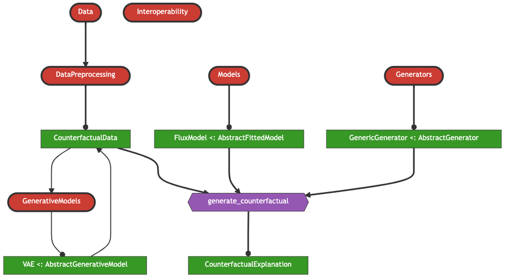

## Generators

```julia
using CounterfactualExplanations, Plots, GraphRecipes
plt = plot(AbstractGenerator, method=:tree, fontsize=10, nodeshape=:rect, size=(1000,700))
savefig(plt, joinpath(www_path,"generators.png"))
```

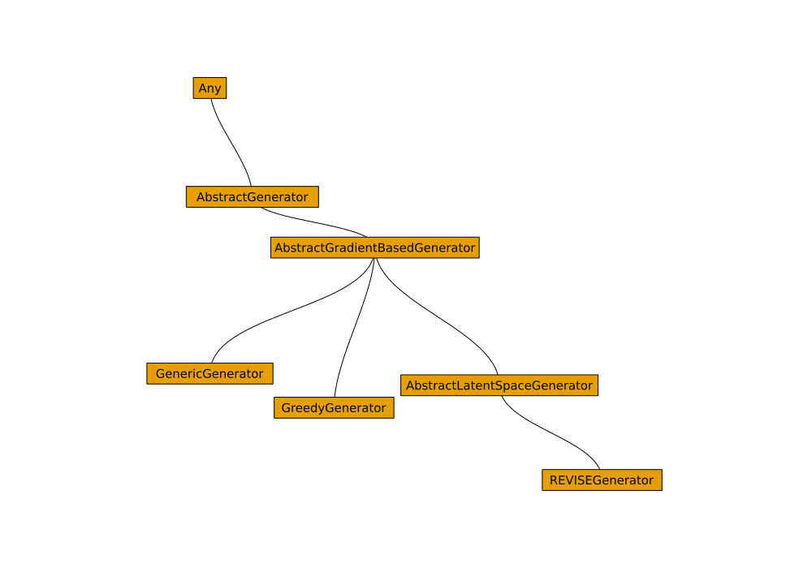

Figure 7: Type tree for `AbstractGenerator`.

## Models

```julia
plt = plot(AbstractFittedModel, method=:tree, fontsize=10, nodeshape=:rect, size=(1000,700))
savefig(plt, joinpath(www_path,"models.png"))
```

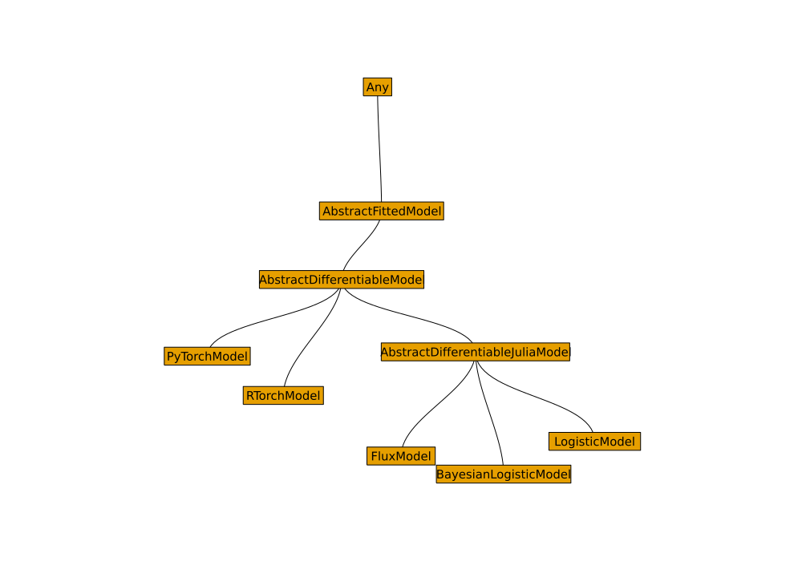

Figure 8: Type tree for `AbstractFittedModel`.

# Basic Usage

## A simple example

1. Load and prepare some toy data.
2. Select a random sample.
3. Generate counterfactuals using different approaches.

```julia
# Data:
using Random
Random.seed!(123)
N = 100
using CounterfactualExplanations
xs, ys = toy_data_linear(N)
X = hcat(xs...)
counterfactual_data = CounterfactualData(X,ys')

# Randomly selected factual:
x = select_factual(counterfactual_data,rand(1:size(X)[2]))
```

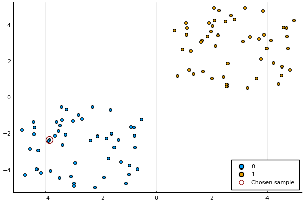

Figure 9: Synthetic data.

## Generic Generator

#### Code

We begin by instantiating the fitted model …

```julia
# Model
w = [1.0 1.0] # estimated coefficients
b = 0 # estimated bias
M = LogisticModel(w, [b])
```

… then based on its prediction for $x$ we choose the opposite label as our target …

```julia
# Select target class:
y = round(probs(M, x)[1])
target = ifelse(y==1.0,0.0,1.0) # opposite label as target
```

… and finally generate the counterfactual.

```julia
# Counterfactual search:
generator = GenericGenerator()
counterfactual = generate_counterfactual(
  x, target, counterfactual_data, M, generator
)
```

#### Output

> … et voilà!

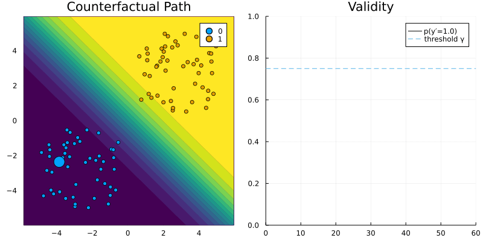

Figure 10: Counterfactual path (left) and predicted probability (right) for `GenericGenerator`. The contour (left) shows the predicted probabilities of the classifier (Logistic Regression).

## Greedy Generator

#### Code

This time we use a Bayesian classifier …

```julia
using LinearAlgebra
Σ = Symmetric(reshape(randn(9),3,3).*0.01 + UniformScaling(1)) # MAP covariance matrix
μ = hcat(b, w)
M = BayesianLogisticModel(μ, Σ)
```

… and once again choose our target label as before …

```julia
# Select target class:
y = round(probs(M, x)[1])
target = ifelse(y==1.0,0.0,1.0) # opposite label as target
```

… to then finally use greedy search to find a counterfactual.

```julia
# Counterfactual search:
params = GreedyGeneratorParams(
  δ = 0.5,
  n = 10
)
generator = GreedyGenerator(;params=params)
counterfactual = generate_counterfactual(
  x, target, counterfactual_data, M, generator
)
```

#### Output

> In this case the Bayesian approach yields a similar outcome.

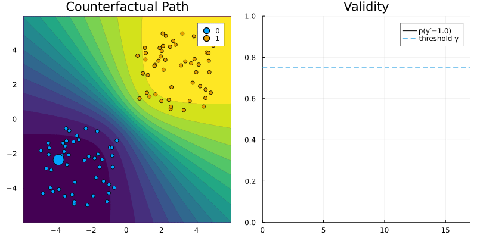

Figure 11: Counterfactual path (left) and predicted probability (right) for `GreedyGenerator`. The contour (left) shows the predicted probabilities of the classifier (Bayesian Logistic Regression).

## REVISE Generator

#### Code

Using the same classifier as before we can either use the specific `REVISEGenerator` …

```julia
# Counterfactual search:
generator = REVISEGenerator()
counterfactual = generate_counterfactual(
  x, target, counterfactual_data, M, generator
)
```

… or realize that that REVISE (Joshi et al. 2019) just boils down to generic search in a latent space:

```julia
# Counterfactual search:
generator = GenericGenerator()
counterfactual = generate_counterfactual(
  x, target, counterfactual_data, M, generator,
  latent_space=true
)
```

#### Output

> We have essentially combined latent search with a probabilistic classifier (as in Antorán et al. (2020)).

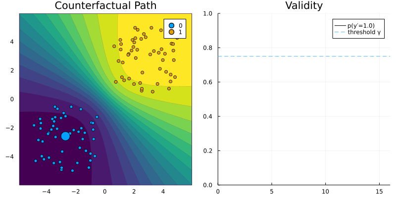

Figure 12: Counterfactual path (left) and predicted probability (right) for `REVISEGenerator`.

## MNIST - Latent Space Search

#### Good VAE

Loading pre-trained classifiers and VAE …

```julia
X, ys = mnist_data()
model = mnist_model() # simple MLP
```

… instantiating model and attaching VAE.

```julia
M = FluxModel(model, likelihood=:classification_multi)
counterfactual_data = CounterfactualData(X,ys)
vae = mnist_vae()
counterfactual_data.generative_model = vae
```

> The results in Figure 13 look great!

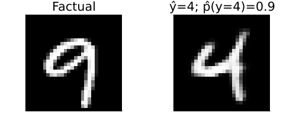

Figure 13: Turning a nine (9) into a four (4) using REVISE. It appears that the VAE is well-specified in this case.

#### Bad VAE

> But things can also go wrong …

The VAE used to generate the counterfactual in Figure 14 is not expressive enough.

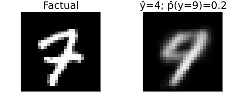

Figure 14: Turning a seven (7) into a nine (9) using REVISE with a weak VAE.

> The counterfactual in Figure 15 is also valid … what to do?

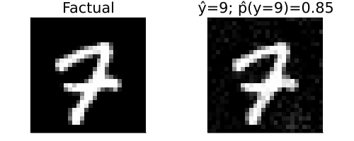

Figure 15: Turning a seven (7) into a nine (9) using generic search.

# Customization

## Custom Models - Deep Ensemble

Loading the pre-trained deep ensemble …

```julia
ensemble = mnist_ensemble() # deep ensemble
```

**Step 1**: add composite type as subtype of `AbstractFittedModel`.

```julia
struct FittedEnsemble <: Models.AbstractFittedModel
    ensemble::AbstractArray
end
```

**Step 2**: dispatch `logits` and `probs` methods for new model type.

```julia
using Statistics
import CounterfactualExplanations.Models: logits, probs
logits(M::FittedEnsemble, X::AbstractArray) = mean(Flux.stack([nn(X) for nn in M.ensemble],3), dims=3)
probs(M::FittedEnsemble, X::AbstractArray) = mean(Flux.stack([softmax(nn(X)) for nn in M.ensemble],3),dims=3)
M = FittedEnsemble(ensemble)
```

> Results for a simple deep ensemble also look convincing!

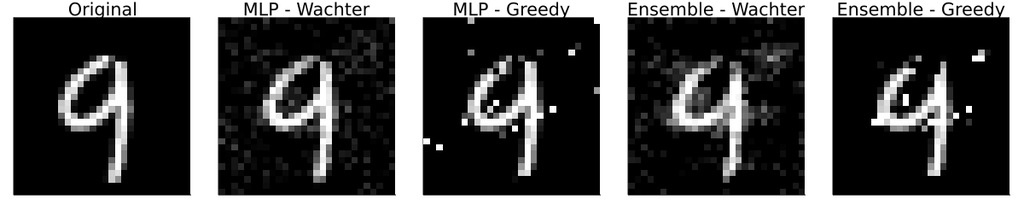

Figure 16: Turning a nine (9) into a four (4) using generic (Wachter) and greedy search for MLP and deep ensemble.

## Custom Models - Interoperability

Adding support for `torch` models was easy! Here’s how I implemented it for `torch` classifiers trained in R.

#### Source code

**Step 1**: add composite type as subtype of `AbstractFittedModel`

> Implemented [here](https://github.com/juliatrustworthyai/CounterfactualExplanations.jl/blob/19795f547d87d561d5906d7966e6fd1022fa8ceb/src/models/differentiable/R.jl#L10).

**Step 2**: dispatch `logits` and `probs` methods for new model type.

> Implemented [here](https://github.com/juliatrustworthyai/CounterfactualExplanations.jl/blob/19795f547d87d561d5906d7966e6fd1022fa8ceb/src/models/differentiable/R.jl#L21).

**Step 3**: add gradient access.

> Implemented [here](https://github.com/juliatrustworthyai/CounterfactualExplanations.jl/blob/19795f547d87d561d5906d7966e6fd1022fa8ceb/src/generators/gradient_based/functions.jl#L22).

#### Unchanged API

```julia
M = RTorchModel(model)
# Select target class:
y = round(probs(M, x)[1])
target = ifelse(y==1.0,0.0,1.0) # opposite label as target
# Define generator:
generator = GenericGenerator()
# Generate recourse:
counterfactual = generate_counterfactual(
  x, target, counterfactual_data, M, generator
)
```

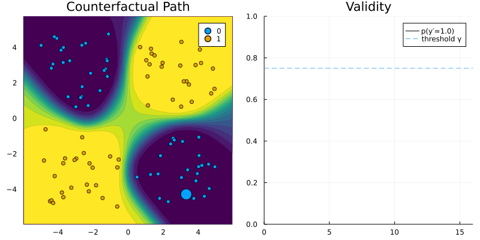

Figure 17: Counterfactual path (left) and predicted probability (right) for `GenericGenerator` and `RTorchModel`.

## Custom Generators

Idea 💡: let’s implement a generic generator with dropout!

#### Dispatch

**Step 1**: create a subtype of `AbstractGradientBasedGenerator` (adhering to some basic rules).

```julia
# Constructor:
abstract type AbstractDropoutGenerator <: AbstractGradientBasedGenerator end
struct DropoutGenerator <: AbstractDropoutGenerator
    loss::Symbol # loss function
    complexity::Function # complexity function
    mutability::Union{Nothing,Vector{Symbol}} # mutibility constraints
    λ::AbstractFloat # strength of penalty
    ϵ::AbstractFloat # step size
    τ::AbstractFloat # tolerance for convergence
    p_dropout::AbstractFloat # dropout rate
end
```

**Step 2**: implement logic for generating perturbations.

```julia
import CounterfactualExplanations.Generators: generate_perturbations, ∇
using StatsBase
function generate_perturbations(generator::AbstractDropoutGenerator, counterfactual_state::State)
    𝐠ₜ = ∇(generator, counterfactual_state.M, counterfactual_state) # gradient
    # Dropout:
    set_to_zero = sample(1:length(𝐠ₜ),Int(round(generator.p_dropout*length(𝐠ₜ))),replace=false)
    𝐠ₜ[set_to_zero] .= 0
    Δx′ = - (generator.ϵ .* 𝐠ₜ) # gradient step
    return Δx′
end
```

#### Unchanged API

```julia
# Instantiate:
using LinearAlgebra
generator = DropoutGenerator(
    :logitbinarycrossentropy,
    norm,
    nothing,
    0.1,
    0.1,
    1e-5,
    0.5
)
counterfactual = generate_counterfactual(
  x, target, counterfactual_data, M, generator
)
```

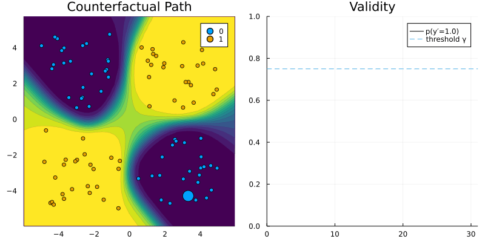

Figure 18: Counterfactual path (left) and predicted probability (right) for custom `DropoutGenerator` and `RTorchModel`.

# Goals and Ambitions 🎯

## JuliaCon 2022 and beyond

#### To JuliaCon …

Develop package, register and submit to [JuliaCon 2022](https://juliacon.org/2022/).

Native support for deep learning models (`Flux`, `torch`).

Add latent space search.

#### … and beyond

- Add more generators:
  - DiCE (Mothilal et al. 2020)
  - ROAR (Upadhyay et al. 2021)
  - MINT (Karimi et al. 2021)
- Add support for more models:
  - `MLJ`, `GLM`, …
  - Non-differentiable
- Enhance preprocessing functionality.
- Extend functionality to regression problems.
- Use `Flux` optimizers.
- …

[figure not shown]

Photo by [Ivan Diaz](https://unsplash.com/@ivvndiaz?utm_source=unsplash&utm_medium=referral&utm_content=creditCopyText) on [Unsplash](https://unsplash.com/?utm_source=unsplash&utm_medium=referral&utm_content=creditCopyText)

## More Resources 📚

> Read on …
- Blog post introducing CE: [[TDS](https://towardsdatascience.com/individual-recourse-for-black-box-models-5e9ed1e4b4cc), [homepage](https://www.patalt.org/blog/posts/individual-recourse-for-black-box-models/)].
- Blog post introducing package: [[TDS](https://towardsdatascience.com/a-new-tool-for-explainable-ai-65834e757c28), [homepage](https://www.patalt.org/blog/posts/a-new-tool-for-explainable-ai/)].
- Package [docs](https://www.patalt.org/CounterfactualExplanations.jl/dev/) with lots of examples.

> … or get involved! 🤗
- [Contributor’s Guide](https://www.patalt.org/CounterfactualExplanations.jl/dev/contributing/)

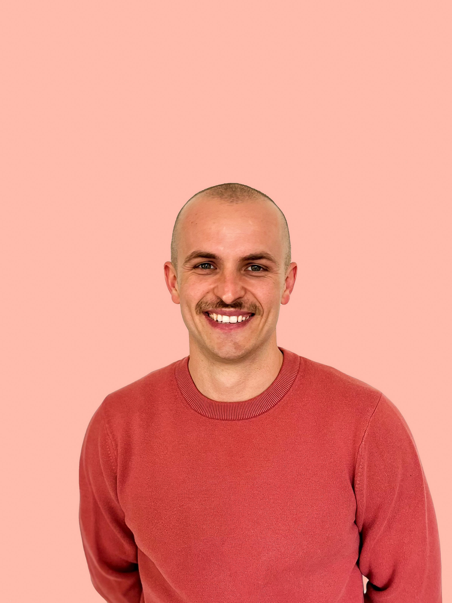

## References

Antorán, Javier, Umang Bhatt, Tameem Adel, Adrian Weller, and José Miguel Hernández-Lobato. 2020. “Getting a Clue: A Method for Explaining Uncertainty Estimates.” https://arxiv.org/abs/2006.06848.

Goodfellow, Ian, Jonathon Shlens, and Christian Szegedy. 2015. *Explaining and Harnessing Adversarial Examples*. https://arxiv.org/abs/1412.6572.

Joshi, Shalmali, Oluwasanmi Koyejo, Warut Vijitbenjaronk, Been Kim, and Joydeep Ghosh. 2019. *Towards Realistic Individual Recourse and Actionable Explanations in Black-Box Decision Making Systems*. https://arxiv.org/abs/1907.09615.

Karimi, Amir-Hossein, Bernhard Schölkopf, and Isabel Valera. 2021. “Algorithmic Recourse: From Counterfactual Explanations to Interventions.” *Proceedings of the 2021 ACM Conference on Fairness, Accountability, and Transparency* (New York, NY, USA), FAccT '21, 353. https://doi.org/10.1145/3442188.3445899.

Karimi, Amir-Hossein, Julius Von Kügelgen, Bernhard Schölkopf, and Isabel Valera. 2020. “Algorithmic Recourse Under Imperfect Causal Knowledge: A Probabilistic Approach.” https://arxiv.org/abs/2006.06831.

Kaur, Harmanpreet, Harsha Nori, Samuel Jenkins, Rich Caruana, Hanna Wallach, and Jennifer Wortman Vaughan. 2020. “Interpreting Interpretability: Understanding Data Scientists'use of Interpretability Tools for Machine Learning.” *Proceedings of the 2020 CHI Conference on Human Factors in Computing Systems*, 1–14. https://doi.org/10.1145/3313831.3376219.

Mothilal, Ramaravind K, Amit Sharma, and Chenhao Tan. 2020. “Explaining Machine Learning Classifiers Through Diverse Counterfactual Explanations.” *Proceedings of the 2020 Conference on Fairness, Accountability, and Transparency*, 607–17. https://doi.org/10.1145/3351095.3372850.

Murphy, Kevin P. 2022. *Probabilistic Machine Learning: An Introduction*. MIT Press.

Pawelczyk, Martin, Sascha Bielawski, Johannes van den Heuvel, Tobias Richter, and Gjergji Kasneci. 2021. *CARLA: A Python Library to Benchmark Algorithmic Recourse and Counterfactual Explanation Algorithms*. https://arxiv.org/abs/2108.00783.

Poyiadzi, Rafael, Kacper Sokol, Raul Santos-Rodriguez, Tijl De Bie, and Peter Flach. 2020. “FACE: Feasible and Actionable Counterfactual Explanations.” *Proceedings of the AAAI/ACM Conference on AI, Ethics, and Society*, 344–50.

Rudin, Cynthia. 2019. “Stop Explaining Black Box Machine Learning Models for High Stakes Decisions and Use Interpretable Models Instead.” *Nature Machine Intelligence* 1 (5): 206–15. https://doi.org/10.1038/s42256-019-0048-x.

Schut, Lisa, Oscar Key, Rory McGrath, et al. 2021. “Generating Interpretable Counterfactual Explanations by Implicit Minimisation of Epistemic and Aleatoric Uncertainties.” *International Conference on Artificial Intelligence and Statistics*, 1756–64.

Slack, Dylan, Sophie Hilgard, Emily Jia, Sameer Singh, and Himabindu Lakkaraju. 2020. “Fooling Lime and Shap: Adversarial Attacks on Post Hoc Explanation Methods.” *Proceedings of the AAAI/ACM Conference on AI, Ethics, and Society*, 180–86.

Upadhyay, Sohini, Shalmali Joshi, and Himabindu Lakkaraju. 2021. “Towards Robust and Reliable Algorithmic Recourse.” *Advances in Neural Information Processing Systems* 34: 16926–37.

Ustun, Berk, Alexander Spangher, and Yang Liu. 2019. “Actionable Recourse in Linear Classification.” *Proceedings of the Conference on Fairness, Accountability, and Transparency*, 10–19. https://doi.org/10.1145/3287560.3287566.

Wachter, Sandra, Brent Mittelstadt, and Chris Russell. 2017. “Counterfactual Explanations Without Opening the Black Box: Automated Decisions and the GDPR.” *Harv. JL \& Tech.* 31: 841. https://doi.org/10.2139/ssrn.3063289.

Wilson, Andrew Gordon. 2020. *The Case for Bayesian Deep Learning*. https://arxiv.org/abs/2001.10995.